# Computer Vision: Plant Seedlings Classification Project 8

## January 2023

## Problem Statement

"The Aarhus University Signal Processing group, in collaboration with the University of Southern Denmark, has provided the data containing images of unique plants belonging to 12 different species. Build a Convolutional Neural Network model which would classify the plant seedlings into their respective 12 categories."

### Data Decription

"This dataset contains images of unique plants belonging to 12 different species. The data file names are: images.npy Label.csv Due to the large volume of data, the images were converted to numpy arrays and stored in images.npy file and the corresponding labels are also put into Labels.csv so that you can work on the data/project seamlessly without having to worry about the high data volume. The goal of the project is to create a classifier capable of determining a plant's species from an image." List of Plant species

- Black-grass
- Charlock
- Cleavers
- Common Chickweed
- Common Wheat
- Fat Hen
- Loose Silky-bent
- Maize
- Scentless Mayweed
- Shepherds
- Small-flowered Cranesbill
- Sugar beet

## Dataset Load and Summary Using Code from CNN Sequential Model hands - on notebook )

- Read the dataset properly
- Print the overview of the data (shape, checking the proportion of each class)
- Plot the images from each class and print their corresponding labels.

```python
import pandas as pd
import numpy as np
import matplotlib.pyplot as plt
import seaborn as sns
import math
import cv2

import tensorflow as tf

# Keras Sequential Model
from tensorflow.keras.models import Sequential

# Importing all the different layers and optimizers
from tensorflow.keras.layers import Dense, Dropout, Flatten, Conv2D, MaxPooling2D, BatchNormalization, Activation, LeakyReLU
from tensorflow.keras.optimizers import Adam,SGD

# The below code can be used to ignore the warnings that may occur due to deprecations
import warnings
warnings.filterwarnings("ignore")
```

```python
# using code from Monkey Species Classification session notebook
# Load the image file of the dataset
images = np.load('images.npy')

# Load the labels file of the dataset
labels = pd.read_csv('Labels.csv')
```

```python
# using code from Monkey Species Classification session notebook
print(images.shape)
print(labels.shape)
```

```
(4750, 128, 128, 3)
(4750, 1)
```

#### There are 4750 RGB images of shape 128 x 128 x3; each image has 3 channels

### Plotting images (using code from Monkey Species Classification session notebook)

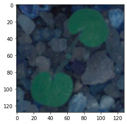

```python
plt.imshow(images[5])
```

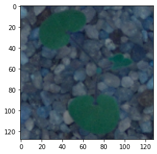

```python
plt.imshow(images[6])
```

```python
%matplotlib inline
```

```python
def plot_images(images,labels):
  num_classes=12                                                                  # Number of Classes
  categories=np.unique(labels)
  keys=dict(labels['Label'])                                                      # Obtaing the unique classes from y_train
  rows = 3                                                                        # Defining number of rows=3
  cols = 4                                                                        # Defining number of columns=4
  fig = plt.figure(figsize=(10, 8))                                               # Defining the figure size to 10x8
  for i in range(cols):
      for j in range(rows):
          random_index = np.random.randint(0, len(labels))                        # Generating random indices from the data and plotting the images
          ax = fig.add_subplot(rows, cols, i * rows + j + 1)                      # Adding subplots with 3 rows and 4 columns
          ax.imshow(images[random_index, :])                                      # Plotting the image
          ax.set_title(keys[random_index])
  plt.show()
```

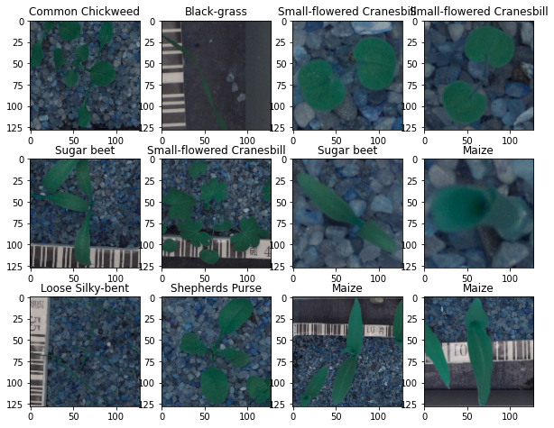

```python
#print a subset of images
plot_images(images,labels)
```

## Exploratory data analysis

- Count Plot for each category (using code from Monkey Species Classification session notebook)
- Any other exploratory deep dive

```
(array([ 0,  1,  2,  3,  4,  5,  6,  7,  8,  9, 10, 11]),
 [Text(0, 0, 'Small-flowered Cranesbill'),
```

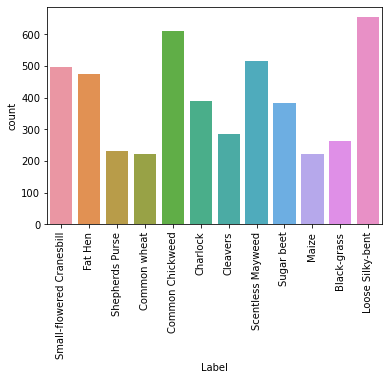

```python
sns.countplot(labels['Label'])
plt.xticks(rotation='vertical')
```

```python
# Storing the value counts of target variable (code from food image classification notebook)
count=labels.value_counts()
print(count)
print('*'*10)
count=labels.value_counts(normalize=True)
print(count)
```

```
Label
Loose Silky-bent             654
Common Chickweed             611
Scentless Mayweed            516
Small-flowered Cranesbill    496
Fat Hen                      475
Charlock                     390
Sugar beet                   385
Cleavers                     287
Black-grass                  263
Shepherds Purse              231
Common wheat                 221
Maize                        221
dtype: int64
**********
Label
Loose Silky-bent             0.137684
Common Chickweed             0.128632
Scentless Mayweed            0.108632
Small-flowered Cranesbill    0.104421
Fat Hen                      0.100000
Charlock                     0.082105
Sugar beet                   0.081053
Cleavers                     0.060421
Black-grass                  0.055368
Shepherds Purse              0.048632
Common wheat                 0.046526
Maize                        0.046526
dtype: float64
```

## EDA Insights

- Key meaningful observations from EDA

Data set is imbalanced; plants per category varies among the 12 categories. Consider one of the following techniques to remove bias towrd the classes with higher frequency

- Chipping
- Merging near-identical classes (requires help from domain expert)
- resampling specific classes
- adjusting the loss function

https://towardsdatascience.com/4-ways-to-improve-class-imbalance-for-image-data-9adec8f390f1

## Data Preprocessing

- Remove unwanted noise from the images using Gaussian Blurring
- Apply the normalization -Plot the images before and after the pre-processing steps
- Split the data into train and test

#### Apply Gaussian Blur

```python
# Applying Gaussian Blur to denoise the images (using code from Monkey Species Classification session notebook)
images_gb=[]
for i in range(len(images)):
  # gb[i] = cv2.cvtColor(images[i], cv2.COLOR_BGR2RGB)
  images_gb.append(cv2.GaussianBlur(images[i], ksize =(3,3),sigmaX =  0))
```

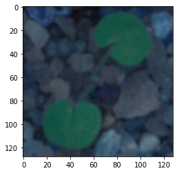

```python
plt.imshow(images_gb[5])
```

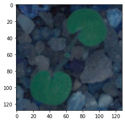

```python
# Compare to image 5 after gaussian blur to image 5 before Gaussian blur
plt.imshow(images[5])
```

```python
#### Split data (using images where gaussian blur has been applied into training and test (using code from Monkey Species Classification session notebook)
```

```python
from sklearn.model_selection import train_test_split
X_temp, X_test, y_temp, y_test = train_test_split(np.array(images_gb),labels , test_size=0.1, random_state=42,stratify=labels)
X_train, X_val, y_train, y_val = train_test_split(X_temp,y_temp , test_size=0.1, random_state=42,stratify=y_temp)
```

```python
print(X_train.shape,y_train.shape)
print(X_val.shape,y_val.shape)
print(X_test.shape,y_test.shape)
```

```
(3847, 128, 128, 3) (3847, 1)
(428, 128, 128, 3) (428, 1)
(475, 128, 128, 3) (475, 1)
```

```
(array([ 0,  1,  2,  3,  4,  5,  6,  7,  8,  9, 10, 11]),
 [Text(0, 0, 'Shepherds Purse'),
```

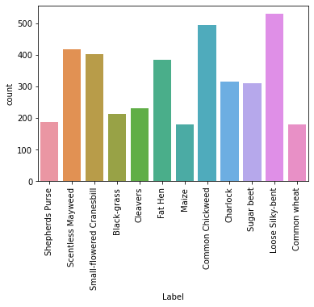

```python
# Check balance of training data and compare to balance of validation and test data
sns.countplot(y_train['Label'])
plt.xticks(rotation='vertical')
```

```
(array([ 0,  1,  2,  3,  4,  5,  6,  7,  8,  9, 10, 11]),
 [Text(0, 0, 'Loose Silky-bent'),
```

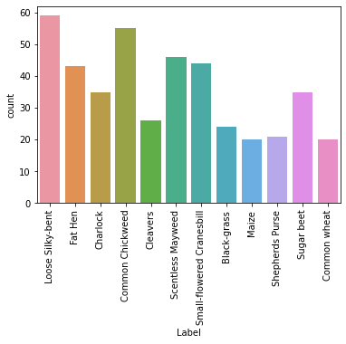

```python
sns.countplot(y_val['Label'])
plt.xticks(rotation='vertical')
```

```
(array([ 0,  1,  2,  3,  4,  5,  6,  7,  8,  9, 10, 11]),
 [Text(0, 0, 'Common Chickweed'),
```

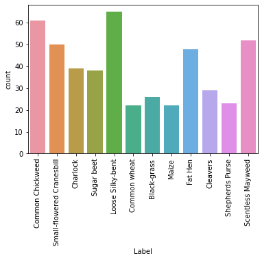

```python
sns.countplot(y_test['Label'])
plt.xticks(rotation='vertical')
```

### NOTE: In future models, consider applying methods to (above) to balance the datasets; for now continue.

#### Apply normalization (using code from Monkey Species Classification session notebook)

```python
X_train_normalized = X_train.astype('float32')/255.0
X_val_normalized = X_val.astype('float32')/255.0
X_test_normalized = X_test.astype('float32')/255.0
```

## Data Compatibility

- Convert labels from digits to one hot vector
- Check the shape of the data. Reshape the data into shapes compatible with Keras models, if already not compatible.

```python
### From CIFAR - 10 Image Classification Notebook,
"In Keras, The input features are 4-dimensional for a Conv2D layer.
Here, we already have 4-dimensional input as these are colored images."

Therefore, I aam not reshaping the data.
```

```python
from sklearn.preprocessing import LabelBinarizer
enc = LabelBinarizer()
y_train_encoded = enc.fit_transform(y_train)
y_val_encoded=enc.transform(y_val)
y_test_encoded=enc.transform(y_test)
```

```python
print(y_train_encoded.shape)
print(y_val_encoded.shape)
print(y_test_encoded.shape)
```

```
(3847, 12)
(428, 12)
(475, 12)
```

## Model Build (using code from Monkey Species Classification session notebook)

- Build Convolution Neural Network
- Use different layers in the model

```python
# Fixing the seed for random number generators
import random
np.random.seed(42)
random.seed(42)
tf.random.set_seed(42)
```

```python
# Intializing a sequential model
model = Sequential()

# Adding first conv layer with 64 filters and kernel size 3x3 , padding 'same' provides the output size same as the input size
# Input_shape denotes input image dimension of images
model.add(Conv2D(128, (3, 3), activation='relu', padding="same", input_shape=(128, 128, 3)))

# Adding max pooling to reduce the size of output of first conv layer
model.add(MaxPooling2D((2, 2), padding = 'same'))

model.add(Conv2D(64, (3, 3), activation='relu', padding="same"))
model.add(MaxPooling2D((2, 2), padding = 'same'))

# flattening the output of the conv layer after max pooling to make it ready for creating dense connections
model.add(Flatten())

# Adding a fully connected dense layer with 100 neurons
model.add(Dense(32, activation='relu'))
model.add(Dropout(0.3))
# Adding the output layer with 10 neurons and activation functions as softmax since this is a multi-class classification problem
model.add(Dense(12, activation='softmax'))

# Using SGD Optimizer
# opt = SGD(learning_rate=0.01, momentum=0.9)
opt=Adam()
# Compile model
model.compile(optimizer=opt, loss='categorical_crossentropy', metrics=['accuracy'])

# Generating the summary of the model
model.summary()
```

```
Model: "sequential_2"
_________________________________________________________________
 Layer (type)                Output Shape              Param #
=================================================================
 conv2d_4 (Conv2D)           (None, 128, 128, 128)     3584

 max_pooling2d_4 (MaxPooling  (None, 64, 64, 128)      0
 2D)

 conv2d_5 (Conv2D)           (None, 64, 64, 64)        73792

 max_pooling2d_5 (MaxPooling  (None, 32, 32, 64)       0
 2D)

 flatten_2 (Flatten)         (None, 65536)             0

 dense_4 (Dense)             (None, 32)                2097184

 dropout_2 (Dropout)         (None, 32)                0

 dense_5 (Dense)             (None, 12)                396

=================================================================
Total params: 2,174,956
Trainable params: 2,174,956
Non-trainable params: 0
_________________________________________________________________
```

```python
#### Model 1 Fitting
```

```python
history_1 = model.fit(
            X_train_normalized, y_train_encoded,
            epochs=30,
            validation_data=(X_val_normalized,y_val_encoded),
            batch_size=32,
            verbose=2
)
```

```
121/121 - 292s - loss: 2.2994 - accuracy: 0.2056 - val_loss: 1.8779 - val_accuracy: 0.3692 - 292s/epoch - 2s/step
121/121 - 258s - loss: 1.8983 - accuracy: 0.3171 - val_loss: 1.5927 - val_accuracy: 0.4416 - 258s/epoch - 2s/step
121/121 - 228s - loss: 1.6902 - accuracy: 0.3785 - val_loss: 1.4132 - val_accuracy: 0.5234 - 228s/epoch - 2s/step
121/121 - 308s - loss: 1.5767 - accuracy: 0.4338 - val_loss: 1.3400 - val_accuracy: 0.5537 - 308s/epoch - 3s/step
121/121 - 141s - loss: 1.4889 - accuracy: 0.4614 - val_loss: 1.2507 - val_accuracy: 0.5911 - 141s/epoch - 1s/step
121/121 - 94s - loss: 1.4574 - accuracy: 0.4799 - val_loss: 1.2000 - val_accuracy: 0.5935 - 94s/epoch - 775ms/step
121/121 - 93s - loss: 1.4229 - accuracy: 0.4791 - val_loss: 1.2216 - val_accuracy: 0.5958 - 93s/epoch - 767ms/step
121/121 - 101s - loss: 1.3643 - accuracy: 0.4947 - val_loss: 1.1969 - val_accuracy: 0.6098 - 101s/epoch - 836ms/step
121/121 - 125s - loss: 1.3258 - accuracy: 0.5105 - val_loss: 1.1735 - val_accuracy: 0.5958 - 125s/epoch - 1s/step
121/121 - 125s - loss: 1.3021 - accuracy: 0.5246 - val_loss: 1.2399 - val_accuracy: 0.5818 - 125s/epoch - 1s/step
121/121 - 123s - loss: 1.3096 - accuracy: 0.5035 - val_loss: 1.2223 - val_accuracy: 0.6098 - 123s/epoch - 1s/step
121/121 - 126s - loss: 1.2692 - accuracy: 0.5251 - val_loss: 1.1041 - val_accuracy: 0.6215 - 126s/epoch - 1s/step
121/121 - 128s - loss: 1.2646 - accuracy: 0.5279 - val_loss: 1.1251 - val_accuracy: 0.6308 - 128s/epoch - 1s/step
121/121 - 119s - loss: 1.2178 - accuracy: 0.5409 - val_loss: 1.1487 - val_accuracy: 0.6098 - 119s/epoch - 983ms/step
121/121 - 111s - loss: 1.2158 - accuracy: 0.5324 - val_loss: 1.1544 - val_accuracy: 0.6028 - 111s/epoch - 916ms/step
121/121 - 148s - loss: 1.2147 - accuracy: 0.5412 - val_loss: 1.1198 - val_accuracy: 0.6192 - 148s/epoch - 1s/step
121/121 - 209s - loss: 1.1939 - accuracy: 0.5521 - val_loss: 1.1007 - val_accuracy: 0.6402 - 209s/epoch - 2s/step
121/121 - 190s - loss: 1.1603 - accuracy: 0.5654 - val_loss: 1.0714 - val_accuracy: 0.6379 - 190s/epoch - 2s/step
121/121 - 505s - loss: 1.1709 - accuracy: 0.5630 - val_loss: 1.1068 - val_accuracy: 0.6262 - 505s/epoch - 4s/step
121/121 - 526s - loss: 1.1342 - accuracy: 0.5701 - val_loss: 1.0899 - val_accuracy: 0.6402 - 526s/epoch - 4s/step
121/121 - 2037s - loss: 1.1311 - accuracy: 0.5708 - val_loss: 1.0844 - val_accuracy: 0.6262 - 2037s/epoch - 17s/step
121/121 - 84s - loss: 1.0958 - accuracy: 0.5760 - val_loss: 1.0471 - val_accuracy: 0.6636 - 84s/epoch - 697ms/step
121/121 - 77s - loss: 1.0947 - accuracy: 0.5727 - val_loss: 1.1482 - val_accuracy: 0.6355 - 77s/epoch - 636ms/step
121/121 - 79s - loss: 1.1095 - accuracy: 0.5695 - val_loss: 1.1982 - val_accuracy: 0.6285 - 79s/epoch - 656ms/step
121/121 - 81s - loss: 1.0928 - accuracy: 0.5766 - val_loss: 1.0855 - val_accuracy: 0.6519 - 81s/epoch - 672ms/step
121/121 - 80s - loss: 1.0841 - accuracy: 0.5812 - val_loss: 1.1053 - val_accuracy: 0.6379 - 80s/epoch - 665ms/step
121/121 - 83s - loss: 1.0571 - accuracy: 0.5911 - val_loss: 1.1667 - val_accuracy: 0.6238 - 83s/epoch - 688ms/step
121/121 - 90s - loss: 1.0445 - accuracy: 0.5997 - val_loss: 1.1614 - val_accuracy: 0.6192 - 90s/epoch - 741ms/step
121/121 - 86s - loss: 1.0528 - accuracy: 0.5963 - val_loss: 1.1285 - val_accuracy: 0.6495 - 86s/epoch - 714ms/step
121/121 - 92s - loss: 0.9992 - accuracy: 0.6119 - val_loss: 1.1633 - val_accuracy: 0.6332 - 92s/epoch - 764ms/step
```

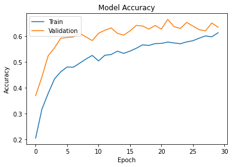

```python
plt.plot(history_1.history['accuracy'])
plt.plot(history_1.history['val_accuracy'])
plt.title('Model Accuracy')
plt.ylabel('Accuracy')
plt.xlabel('Epoch')
plt.legend(['Train', 'Validation'], loc='upper left')
plt.show()
```

```python
# Here we would get the output as probablities for each category
y_pred_val=model.predict(X_val_normalized)
```

```python
y_pred_val
```

```
array([[2.5666382e-02, 1.2196818e-05, 7.1788738e-03, ..., 6.4765877e-04,
        1.9957486e-06, 2.7213484e-02],
       [5.6806538e-02, 3.2328637e-05, 3.5680874e-05, ..., 5.5245971e-03,
        2.9835301e-03, 3.7152591e-01],
       [2.9616324e-13, 2.1480854e-01, 3.4021226e-01, ..., 1.7432244e-01,
        1.2975476e-02, 4.1462501e-04],
       ...,
       [3.1932104e-01, 2.6548561e-10, 7.2949007e-08, ..., 1.2725815e-08,
        5.6198188e-09, 7.1360108e-07],
       [2.4831435e-09, 1.0126305e-15, 2.1784189e-16, ..., 1.2615352e-04,
        2.9994293e-08, 2.1425767e-05],
       [1.0754394e-01, 4.2579263e-11, 2.0561645e-08, ..., 1.2026946e-08,
        8.3509155e-09, 9.1925664e-08]], dtype=float32)
```

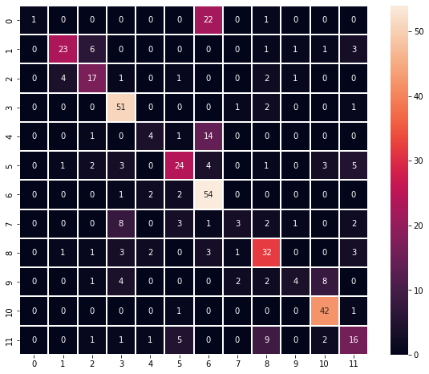

```python
# Obtaining the categorical values from y_test_encoded and y_pred
y_pred_val_arg=np.argmax(y_pred_val,axis=1)
y_val_arg=np.argmax(y_val_encoded,axis=1)

# Plotting the Confusion Matrix using confusion matrix() function which is also predefined tensorflow module
confusion_matrix = tf.math.confusion_matrix(y_val_arg,y_pred_val_arg)
f, ax = plt.subplots(figsize=(10, 8))
sns.heatmap(
    confusion_matrix,
    annot=True,
    linewidths=.4,
    fmt="d",
    square=True,
    ax=ax
)
plt.show()
```

## Model Performance Improvement (using code from Monkey Species Classification session notebook)

- Comment on model performance
- Can model performance be improved? check and comment
- Build another model to implement these improvements Model Performance Improvement

##### Observations on validation data

Model performance can be likely be improved. I will try to improve the model with data augmentation and Batch Normalization.

### Build second model

```python
# Clearing backend
from tensorflow.keras import backend
backend.clear_session()

# Fixing the seed for random number generators
import random
np.random.seed(42)
random.seed(42)
tf.random.set_seed(42)
```

```python
from tensorflow.keras.preprocessing.image import ImageDataGenerator
```

```python
# All images to be rescaled by 1/255.
train_datagen = ImageDataGenerator(
                              rotation_range=20,
                              fill_mode='nearest'
                              )
# test_datagen  = ImageDataGenerator(rescale = 1.0/255.)
```

```python
# Intializing a sequential model
model = Sequential()

# Adding first conv layer with 64 filters and kernel size 3x3 , padding 'same' provides the output size same as the input size
# Input_shape denotes input image dimension images
model.add(Conv2D(128, (3, 3), activation='relu', padding="same", input_shape=(128, 128, 3)))

# Adding max pooling to reduce the size of output of first conv layer
model.add(MaxPooling2D((2, 2), padding = 'same'))
# model.add(BatchNormalization())
model.add(Conv2D(64, (3, 3), activation='relu', padding="same"))
model.add(MaxPooling2D((2, 2), padding = 'same'))
model.add(BatchNormalization())
# flattening the output of the conv layer after max pooling to make it ready for creating dense connections
model.add(Flatten())

# Adding a fully connected dense layer with 100 neurons
model.add(Dense(32, activation='relu'))
model.add(Dropout(0.3))
# Adding the output layer with 10 neurons and activation functions as softmax since this is a multi-class classification problem
model.add(Dense(12, activation='softmax'))

# Using SGD Optimizer
# opt = SGD(learning_rate=0.01, momentum=0.9)
opt=Adam()
# Compile model
model.compile(optimizer=opt, loss='categorical_crossentropy', metrics=['accuracy'])

# Generating the summary of the model
model.summary()
```

```
Model: "sequential"
_________________________________________________________________
 Layer (type)                Output Shape              Param #
=================================================================
 conv2d (Conv2D)             (None, 128, 128, 128)     3584

 max_pooling2d (MaxPooling2D  (None, 64, 64, 128)      0
 )

 conv2d_1 (Conv2D)           (None, 64, 64, 64)        73792

 max_pooling2d_1 (MaxPooling  (None, 32, 32, 64)       0
 2D)

 batch_normalization (BatchN  (None, 32, 32, 64)       256
 ormalization)

 flatten (Flatten)           (None, 65536)             0

 dense (Dense)               (None, 32)                2097184

 dropout (Dropout)           (None, 32)                0

 dense_1 (Dense)             (None, 12)                396

=================================================================
Total params: 2,175,212
Trainable params: 2,175,084
Non-trainable params: 128
_________________________________________________________________
```

```python
# Epochs
epochs = 25
# Batch size
batch_size = 64

history_2 = model.fit(train_datagen.flow(X_train_normalized,y_train_encoded,
                                       batch_size=batch_size,
                                       seed=42,
                                       shuffle=False),
                    epochs=epochs,
                    steps_per_epoch=X_train_normalized.shape[0] // batch_size,
                    validation_data=(X_val_normalized,y_val_encoded),
                    verbose=1)
```

[output not shown]

## Model Performance Evaluation ((using code from Monkey Species Classification session notebook)

- Evaluate the model on different performance metrics and comment on the performance and scope of improvement. For example precision, recall, accuracy.
- Plot confusion matrix for all the models and comment on those.
- All the metrics should be calculated for every model.

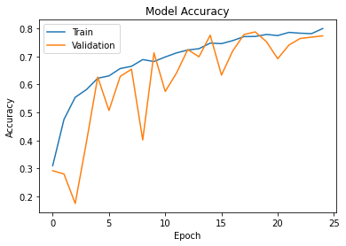

```python
plt.plot(history_2.history['accuracy'])
plt.plot(history_2.history['val_accuracy'])
plt.title('Model Accuracy')
plt.ylabel('Accuracy')
plt.xlabel('Epoch')
plt.legend(['Train', 'Validation'], loc='upper left')
plt.show()
```

### Accuracy of model on Test set

```python
accuracy = model.evaluate(X_test_normalized, y_test_encoded, verbose=2)
```

```
15/15 - 2s - loss: 0.9331 - accuracy: 0.7663 - 2s/epoch - 165ms/step
```

### Model 2 Evaluation

Model 2 which applied Batch Normalization appears to have improved model accuracy from approximately 60% to Approximately 77%. a significant improvement.

### Model 2 Confusion matrix

```python
y_pred=model.predict(X_test_normalized)
```

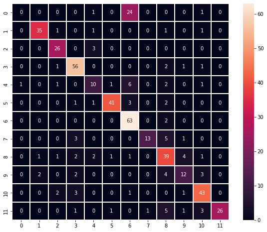

```python
# Obtaining the categorical values from y_test_encoded and y_pred
y_pred_arg=np.argmax(y_pred,axis=1)
y_test_arg=np.argmax(y_test_encoded,axis=1)

# Plotting the Confusion Matrix using confusion matrix() function which is also predefined tensorflow module
confusion_matrix = tf.math.confusion_matrix(y_test_arg,y_pred_arg)
f, ax = plt.subplots(figsize=(10, 8))
sns.heatmap(
    confusion_matrix,
    annot=True,
    linewidths=.4,
    fmt="d",
    square=True,
    ax=ax
)
plt.show()
```

#### Model 2 Observations

- 4, 7 and 9 class predictions improved significantly
- Class 0 is not being predicted well while class 6 is over predicted significantly
- Class 6 is predicteed accurately but also is consistenlty predicted for classes 0 and 4, which is a significant problem for the model
- Class 3 is also predicted wrongly for other classes.

## Conclusions and Takeaways

- Final conclusion about the analysis
- Neither model is making predictions well although model 2 does not appear to be significantly overfitting the data.

#### Next steps

Apply techniques from those specified in EDA to modify class imbalance in the dataset. Class imbalance may be contributing to the tendency to overpredict class 6 Apply Transfer learning techniques to try to improve the model